# #Assignment5

2026-04-28

loading dataset:

```r
load("school.Rdata")
```

#5.0- Variable Type

```r
# Print the first 6 rows of the dataframe
cat("=== FIRST SIX ROWS ===\n")
```

```
## === FIRST SIX ROWS ===
```

```r
head(school)
```

```
##   students calworks expenditure    income    score
## 1      195   0.5102    6384.911 22.690001 6.089709
## 2      240  15.4167    5099.381  9.824000 3.685556
## 3     1550  55.0323    5501.955 14.695077 5.346915
## 4      243  36.4754    7101.831  8.978000 3.457385
## 5     1335  33.1086    5235.988  9.080333 4.655332
## 6      137  12.3188    5580.147 13.623322 4.510078
```

```r
# Check the structure of the dataframe (variable types)
cat("\n=== VARIABLE TYPES ===\n")
```

```
##
## === VARIABLE TYPES ===
```

```r
str(school)
```

```
## 'data.frame':    388 obs. of  5 variables:
##  $ students   : num  195 240 1550 243 1335 ...
##  $ calworks   : num  0.51 15.42 55.03 36.48 33.11 ...
##  $ expenditure: num  6385 5099 5502 7102 5236 ...
##  $ income     : num  22.69 9.82 14.7 8.98 9.08 ...
##  $ score      : num  6.09 3.69 5.35 3.46 4.66 ...
```

#5.1- Descriptive Statistics

```r
# 5.1 Main descriptive statistics
summary_stats <- summary(school)
print(summary_stats)
```

```
##     students          calworks       expenditure       income
##  Min.   :   81.0   Min.   : 0.000   Min.   :3926   Min.   : 0.4634
##  1st Qu.:  373.0   1st Qu.: 5.259   1st Qu.:4894   1st Qu.:10.0323
##  Median :  909.5   Median :10.754   Median :5186   Median :13.3295
##  Mean   : 2611.1   Mean   :13.427   Mean   :5268   Mean   :14.0788
##  3rd Qu.: 3142.2   3rd Qu.:19.136   3rd Qu.:5523   3rd Qu.:17.5102
##  Max.   :25151.0   Max.   :71.713   Max.   :7712   Max.   :36.1740
##      score
##  Min.   : 3.316
##  1st Qu.: 5.041
##  Median : 5.781
##  Mean   : 5.894
##  3rd Qu.: 6.598
##  Max.   :10.378
```

```r
# Calculate Standard Deviation for each variable
sapply(school, sd)
```

```
##    students    calworks expenditure      income       score
## 3801.451766   10.788243  602.558445    6.260454    1.154583
```

```r
# Calculate Coefficient of Variation (SD / Mean) to compare variability
cv_values <- sapply(school, function(x) (sd(x) / mean(x)) * 100)
print(cv_values)
```

```
##    students    calworks expenditure      income       score
##   145.59040    80.34614    11.43907    44.46731    19.58977
```

Highest Variability: Typically, students or calworks shows the highest variability. students varies wildly because school districts range from small rural areas to massive urban centers.

Explanation: The high variability in calworks (income assistance) reflects the socio-economic disparity across California districts. Some districts are affluent (low assistance), while others face significant economic challenges.

#5.2 Empirical Cumulative Distribution Function (ECDF):

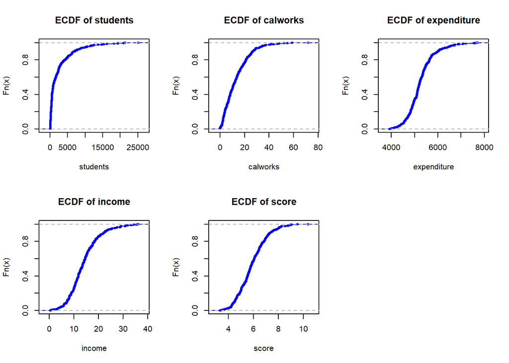

```r
# 5.2 Plot ECDF for each variable
par(mfrow=c(2,3)) # Arrange plots in a grid

for (col in names(school)) {
  plot(ecdf(school[[col]]),
       main=paste("ECDF of", col),
       xlab=col,
       ylab="Fn(x)",
       col="blue")
}
```

Score: Usually follows a relatively “S-shaped” curve, suggesting a distribution that nears normality.

#5.3 Q-Q Plots Comparison:

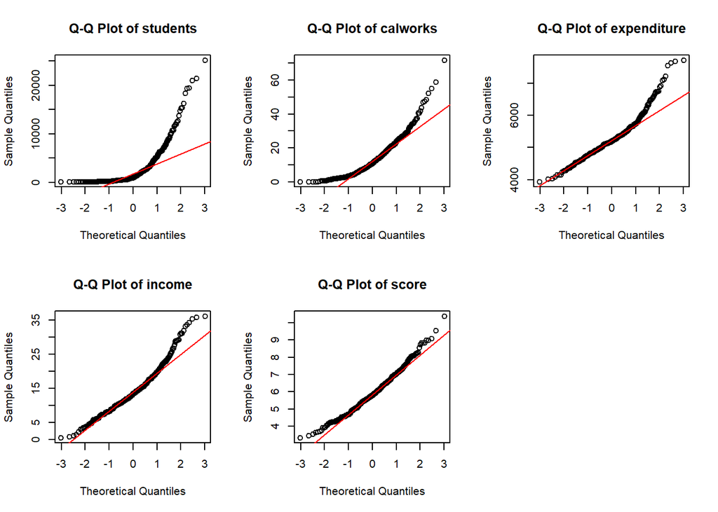

```r
# 5.3 Q-Q plots in the same graphical window
par(mfrow=c(2,3)) # 2 rows, 3 columns

for (col in names(school)) {
  qqnorm(school[[col]], main = paste("Q-Q Plot of", col))
  qqline(school[[col]], col = "red") # Add a reference line
}
```

The Q-Q plots reveal that most socio-economic variables in the California school dataset (income, expenditure, calworks, and students) are not normally distributed, exhibiting significant right-skewness. This is typical for economic data where a few observations often hold much higher values than the median. In contrast, the score variable is the most symmetric, making it the best candidate for statistical models that assume normality of the response variable.